# Mapping and manipulating connections in small animals

2016-11-05T19:50:47+05:30

> “THE most obvious differences between different animals are differences of size, but for some reason the zoologists have paid singularly little attention to them. In a large textbook of zoology before me I find no indication that the eagle is larger than the sparrow, or the hippopotamus bigger than the hare, though some grudging admissions are made in the case of the mouse and the whale. But yet it is easy to show that a hare could not be as large as a hippopotamus, or a while as small as a herring. For every type of animal there is a most convenient size, and a large change in size inevitably carries with it a change of form.” ([J.B.S. Haldane](https://archive.org/stream/OnBeingTheRightSize-J.B.S.Haldane/rightsize_djvu.txt))

### State of play

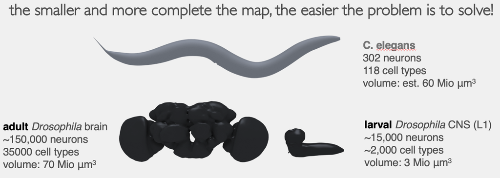

After Ptolemy there was a dark age for world map making, partly because of the immense effort such an enterprise entails. Similarly, after the 14-year *C. elegans* feat (White et al. 1986), the field went quiet. It has now returned, this time with the aid of modern computing. At the time of writing, only two species’ full, published connectomes exist. The *C. elegans*’ connectome of the adult hermaphrodite has 302 (adult male 382) neurons, 6,393 chemical synapses and 890 gap junctions ultimately controlling 95 muscles at 1,410 neuromuscular junctions (Cook et al. 2019; Jarrell et al. 2012; Varshney et al. 2011; White et al. 1986). The connectome of the tadpole larva of the ascidian Ciona intestinalis (Ryan et al. 2016), the closest invertebrate relatives of vertebrates (Delsuc et al. 2006), weighs in at 177 neurons. Additionally, multiple *D. melanogaster* connectomes are on the horizon, ranging from ~15,000-150,000 neurons (Ohyama et al. 2015; Scheffer and Meinertzhagen 2019).

### Electron microscopy can reveal all connections

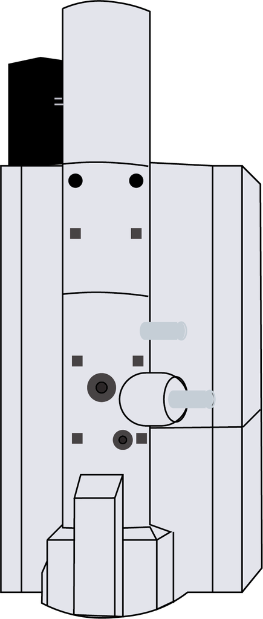

Electron microscopy (EM) is the only means by which to resolve fine neurites (<200 nm, as small as 15 nm (Ian A. Meinertzhagen 2016)), synaptic vesicles (~40 nm) and synaptic clefts (~20 nm) in densely stained tissue, and so see all synaptic connections between neurons in a sample. It provides data that can be mined for both a parts-list and an adjacency matrix of connections between those parts. Other techniques, such as expansion microscopy (Wassie, Zhao, and Boyden 2019), super resolution microscopy (Igarashi et al. 2018) and molecular barcode sequencing (Kebschull and Zador 2018) can provide sparse information on synaptic connectivity or map single neuron’s projections at scale. While they can provide orthogonal useful information, e.g. on gene expression, they lack the morphological and synaptic connectivity ‘completeness’ EM can provide. There is promise that X-ray tomography may provide another avenue to dense circuit reconstruction and allow researchers to use larger tissue volumes than can typically be easily handled with EM pipelines (Kuan et al. 2020).

However, due to the high resolution required to resolve fine neurites and synapses, the EM connectomics produces terabyte-scale datasets for even tissue samples <1 mm3. These datasets are small relative to the size of the nervous systems that neurobiologists typically study, because it is difficult, time-consuming and expensive to section, image, store and extract neuroanatomical data for larger pieces. The field is therefore heavily size restricted. Typically these datasets are only in the millions of cubic microns, and frequently only either a smaller sub-volume has been densely reconstructed (Helmstaedter et al. 2013), or small numbers of neurons have been sparsely reconstructed in a larger volume (Dolan et al. 2019). The image data itself can be acquired by various modern automated methodologies.

Here’s a little summary of modern EM methods and the datasets that have been acquired using them:

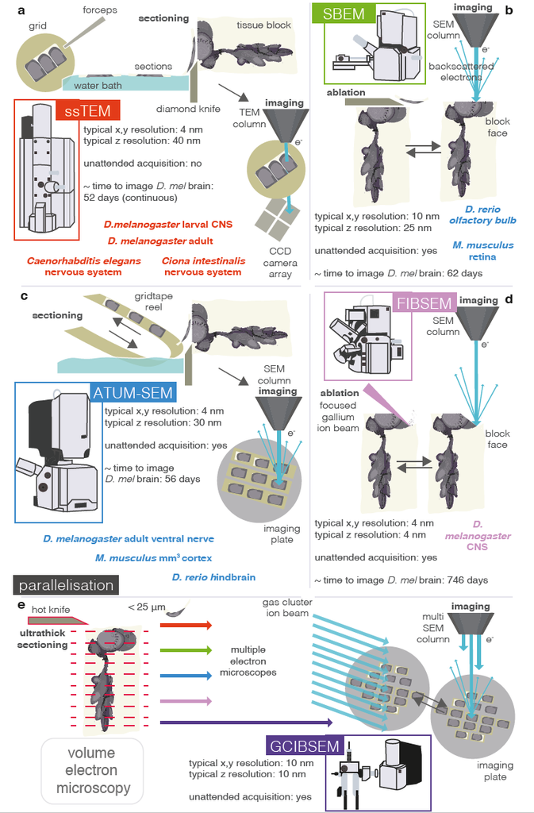

### What did the *C. elegans* connectome do for its neuroscience

Some commentators have criticised the modern shift in neuroscientific research back towards descriptive endeavours such as connectomics (Krakauer et al. 2017), however, the reality is that the *C. elegans* connectome was both immediately useful and continues to be useful today. To consider what a from-connectome approach looks like we can examine the case of the escape response in *C. elegans* (Pirri and Alkema 2012). Early investigators used the connectome to guide laser microsurgery (Chalfie et al. 1985) and genetic perturbations (Y. Zheng et al. 1999), dissociating two motor pathways. Critically they were able to evaluate the interneurons within them, finding four command-like interneurons. The authors could hypothesise which neurons were involved in the forward or backward crawl in response to the activation of touch-sensors, which was later further validated using optogenetics (Leifer et al. 2011) and calcium imaging (Chronis, Zimmer, and Bargmann 2007). They could also predict and test that backward crawl suppressed head-casting movements via a specific set of connections (Pirri et al. 2009). Without the connectome as a guide, investigators would have been less able to make the precise interventions necessary to characterise and implicate these ~13/118 cell types in this circuit.

Once the circuit was established, investigators were able to ask after its behavioural significance. It is known that *C. elegans*’ escape response is required to survive ‘ring’ traps laid by predacious fungi (Pirri and Alkema 2012). Investigators found that touch-sensitive reversal proves key to escaping ring traps (Maguire et al. 2011). Moreover, reversal with head-casting was more likely to trigger these traps than a smooth exit; these mutants with this phenotype were easily outcompeted by the wild-type. By contrast, insect-associating Pleiorhabditis nematodes do not exhibit this suppression, which might be the result of different selection pressures (Pirri and Alkema 2012). An interesting next question will be whether, and if so in what way, do these species’ escape circuits differ; cell type specific synaptogenesis, receptor expression profiles and neurotransmitter use are all likely, evolutionarily labile substrates.

### Why flies are now the frontier

But why not then persist with the *C. elegans* connectome (e.g. for my PhD for example), where there exist significant foundations but not yet a convincing understanding of how different dynamic states in its nervous system result in behaviour? The fly is clearly both complex and efficient. It possesses a highly optimised, innately structured brain for the tasks it is likely to face in its ~32-day life. Similar brains have spread from sub-Saharan Africa to the Arctic, diversifying into ~80,000 species that comprise ~8.5% of the Earth’s ten quintillion insects (McAlister 2017). They are a testament to how evolutionary elaboration on grossly similar neuroanatomy can help an order master a large range of environments.

It is also commonly thought that the behavioural repertoire of the roundworm, and its capacity for more ‘cognitive’ tasks such as learning, is much lesser than the insect (Olsen and Wilson 2008). Unlike roundworms, flies can recognise familiar but displaced objects (Liu et al. 2006; Tang et al. 2004), recall where a displaced object once was (Neuser et al. 2008), respond to small odour concentration changes dependent on the greater sensory context (Faucher et al. 2006) and co-compute olfactory and visual information to direct behaviour on foot (Frye and Dickinson 2004; Guo and Guo 2005) or in-flight (Duistermars and Frye 2008). They can also learn to associate certain stimuli with outcomes, even learning to adapt mating strategies in the face of rejection (Ejima et al. 2007). They can discriminate between pheromones and mating songs of similar *Drosophilids* (Ritchie, Halsey, and Gleason 1999) and fight over resources (Yurkovic et al. 2006).

One of the largest pieces of nervous tissue collected and imaged by EM is a full female adult fly brain (Z. Zheng et al. 2018) known as FAFB. It is 40 teravoxels, 21 million serial section transmission EM camera images, within a 995 x 537 x 283 μm volume at a 4 x 4 x 40 nanometer resolution, and takes up 106 terabytes on disk. Sparse connectomic approaches in this dataset are helping to verify and build a range of behaviorally relevant hypotheses (Z. Zheng et al. 2018; Dolan et al. 2018; Felsenberg et al. 2018; Frechter et al. 2019; Huoviala et al. 2018; Sayin et al. 2018; Bates et al. 2020).

EM methods will soon generate a synaptic-resolution ‘parts lists’ for a small business of flies (perhaps 1-2 larval, 2-3 adult brains and ~2 VNSs in < 5 years), which can be compared to extant, annotated light-level morphologies (Schlegel, Costa, and Jefferis 2017) and leveraged to improve our understanding of circuit computations (e.g. (Takemura et al. 2013)). EM morphologies can also be matched to those revealed by genetic labelling (Davis et al. 2018). Genetic driver lines, especially the intersectional split-GAL4 system, give stable genetic access to small constellations of neuronal types, each of a shared morphology (Dionne et al. 2018; Luan et al. 2006; Pfeiffer et al. 2010). In the best cases, they can selectively label just one morphological neuronal type. I therefore expect strong similarities between subdividing neurons by morphology and by gene expression.

Strong stereotypy in insect nervous systems mean that cell types - which exist in only about 3-5 copies of cell per hemisphere per brain, can be found across different animals in a reproducible manner. Therefore, you can conduct an experiment in, say, many live flies and if you know which cell type you manipulated/recorded from, you can link it to a static connectome from a single, separate dead fly. Like so:

[figure not shown]

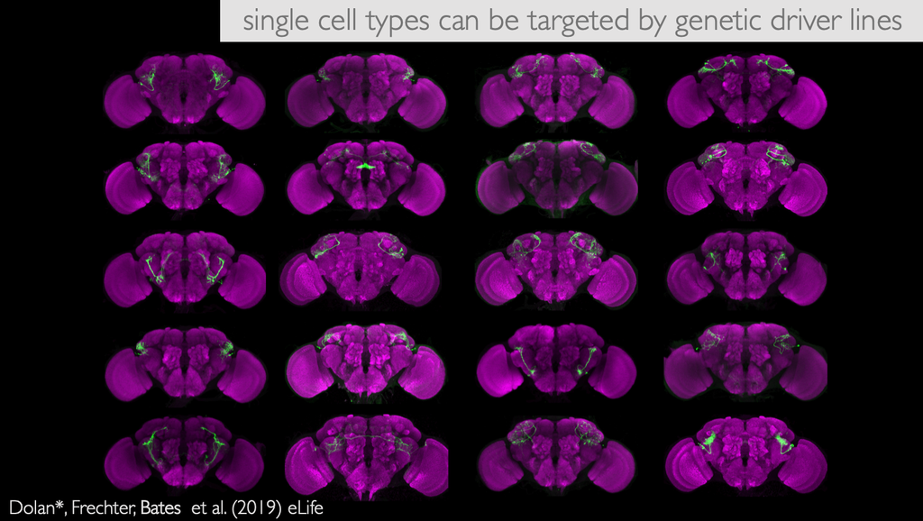

However, one of the great limitations of the fly is also its size. Insect neurites can be thinner than 50 nanometers (I. A. Meinertzhagen and O’Neil 1991), which is about the diameter of a synaptic vesicle. This strains the segmentation of these neurites in ssTEM data, which has a typical Z-resolution of 40-50 nanometers. Section loss through machine and human error can make the z resolution dramatically worse for some neuroanatomical loci (Ohyama et al. 2015). If we consider the input resistance to a neurite of this diameter, it is easy to imagine that the activation of even a single ion channel could result in a membrane voltage fluctuation that rivals that of an action potential. Our understanding of the biophysics of insect neurons is poor, and as the field progresses this will become an increasing burden.

### Concluding thoughts

While connectomes do not provide mechanistic answers to neurobiological questions alone, the connectome is a neuroinformatics scaffold (Swanson and Lichtman 2016) onto which other information can be pinned, such as transcriptomes, cell type annotations, response properties of neurons, etc. However, today’s connectomes are single snapshots of single animals. Even if they are representative of a species, we know that synaptic plasticity is rampant across all studied nervous systems. What is important is whether we can extract connectivity motifs that help explain the potency of innate structure in nervous systems.

### References

Abdelfattah, Ahmed S, Takashi Kawashima, Amrita Singh, Ondrej Novak, Hui Liu, Yichun Shuai, Yi-Chieh Huang, et al. 2018. “Bright and Photostable Chemigenetic Indicators for Extended in Vivo Voltage Imaging.” *bioRxiv*.

Bates, Alexander S, Philipp Schlegel, Ruairi J V Roberts, Nikolas Drummond, Imaan F M Tamimi, Robert Turnbull, Xincheng Zhao, et al. 2020. “Complete Connectomic Reconstruction of Olfactory Projection Neurons in the Fly Brain.” *Curr. Biol.*, June.

Branson, Kristin, Alice A Robie, John Bender, Pietro Perona, and Michael H Dickinson. 2009. “High-Throughput Ethomics in Large Groups of Drosophila.” *Nat. Methods* 6 (6): 451–57.

Chalfie, M, J E Sulston, J G White, E Southgate, J N Thomson, and S Brenner. 1985. “The Neural Circuit for Touch Sensitivity in Caenorhabditis Elegans.” *J. Neurosci.* 5 (4): 956–64.

Chronis, Nikos, Manuel Zimmer, and Cornelia I Bargmann. 2007. “Microfluidics for in Vivo Imaging of Neuronal and Behavioral Activity in Caenorhabditis Elegans.” *Nat. Methods* 4 (9): 727–31.

Cook, Steven J, Travis A Jarrell, Christopher A Brittin, Yi Wang, Adam E Bloniarz, Maksim A Yakovlev, Ken C Q Nguyen, et al. 2019. “Whole-Animal Connectomes of Both Caenorhabditis Elegans Sexes.” *Nature* 571 (7763): 63–71.

Datta, Sandeep Robert, Maria Luisa Vasconcelos, Vanessa Ruta, Sean Luo, Allan Wong, Ebru Demir, Jorge Flores, Karen Balonze, Barry J Dickson, and Richard Axel. 2008. “The Drosophila Pheromone cVA Activates a Sexually Dimorphic Neural Circuit.” *Nature* 452 (7186): 473–77.

Davis, Fred P, Aljoscha Nern, Serge Picard, Michael B Reiser, Gerald M Rubin, Sean R Eddy, and Gilbert L Henry. 2018. “A Genetic, Genomic, and Computational Resource for Exploring Neural Circuit Function.” *bioRxiv*.

Delsuc, Frédéric, Henner Brinkmann, Daniel Chourrout, and Hervé Philippe. 2006. “Tunicates and Not Cephalochordates Are the Closest Living Relatives of Vertebrates.” *Nature* 439 (7079): 965–68.

Dionne, Heather, Karen L Hibbard, Amanda Cavallaro, Jui-Chun Kao, and Gerald M Rubin. 2018. “Genetic Reagents for Making Split-GAL4 Lines in Drosophila.” *Genetics* 209 (1): 31–35.

Dolan, Michael-John, Ghislain Belliart-Guérin, Alexander Shakeel Bates, Shahar Frechter, Aurélie Lampin-Saint-Amaux, Yoshinori Aso, Ruairı́ J V Roberts, et al. 2018. “Communication from Learned to Innate Olfactory Processing Centers Is Required for Memory Retrieval in Drosophila.” *Neuron*, September.

Dolan, Michael-John, Shahar Frechter, Alexander Shakeel Bates, Chuntao Dan, Paavo Huoviala, Ruairı́ Jv Roberts, Philipp Schlegel, et al. 2019. “Neurogenetic Dissection of the Drosophila Lateral Horn Reveals Major Outputs, Diverse Behavioural Functions, and Interactions with the Mushroom Body.” *Elife* 8 (May).

Duistermars, Brian J, and Mark A Frye. 2008. “Crossmodal Visual Input for Odor Tracking During Fly Flight.” *Curr. Biol.* 18 (4): 270–75.

Ejima, Aki, Benjamin P C Smith, Christophe Lucas, Wynand van der Goes van Naters, Carson J Miller, John R Carlson, Joel D Levine, and Leslie C Griffith. 2007. “Generalization of Courtship Learning in Drosophila Is Mediated by Cis-Vaccenyl Acetate.” *Curr. Biol.* 17 (7): 599–605.

Faucher, Cécile, Manfred Forstreuter, Monika Hilker, and Marien de Bruyne. 2006. “Behavioral Responses of Drosophila to Biogenic Levels of Carbon Dioxide Depend on Life-Stage, Sex and Olfactory Context.” *J. Exp. Biol.* 209 (Pt 14): 2739–48.

Felsenberg, Johannes, Pedro F Jacob, Thomas Walker, Oliver Barnstedt, Amelia J Edmondson-Stait, Markus W Pleijzier, Nils Otto, et al. 2018. “Integration of Parallel Opposing Memories Underlies Memory Extinction.” *Cell* 175 (3): 709–722.e15.

Frechter, Shahar, Alexander Shakeel Bates, Sina Tootoonian, Michael-John Dolan, James D Manton, Arian Rokkum Jamasb, Johannes Kohl, Davi Bock, and Gregory Sxe Jefferis. 2019. “Functional and Anatomical Specificity in a Higher Olfactory Centre.” *Elife* 8 (May).

Frye, Mark A, and Michael H Dickinson. 2004. “Motor Output Reflects the Linear Superposition of Visual and Olfactory Inputs in Drosophila.” *J. Exp. Biol.* 207 (Pt 1): 123–31.

Griesbeck, Oliver. 2004. “Fluorescent Proteins as Sensors for Cellular Functions.” *Curr. Opin. Neurobiol.* 14 (5): 636–41.

Guo, Jianzeng, and Aike Guo. 2005. “Crossmodal Interactions Between Olfactory and Visual Learning in Drosophila.” *Science* 309 (5732): 307–10.

Helmstaedter, Moritz, Kevin L Briggman, Srinivas C Turaga, Viren Jain, H Sebastian Seung, and Winfried Denk. 2013. “Connectomic Reconstruction of the Inner Plexiform Layer in the Mouse Retina.” *Nature* 500 (7461): 168–74.

Huoviala, Paavo, Michael-John Dolan, Fiona Love, Shahar Frechter, Ruairi J V Roberts, Zane Mitrevica, Philipp Schlegel, et al. 2018. “Neural Circuit Basis of Aversive Odour Processing in Drosophila from Sensory Input to Descending Output.” *bioRxiv*.

Igarashi, Michihiro, Motohiro Nozumi, Ling-Gang Wu, Francesca Cella Zanacchi, István Katona, László Barna, Pingyong Xu, Mingshu Zhang, Fudong Xue, and Edward Boyden. 2018. “New Observations in Neuroscience Using Superresolution Microscopy.” *J. Neurosci.* 38 (44): 9459–67.

Jarrell, Travis A, Yi Wang, Adam E Bloniarz, Christopher A Brittin, Meng Xu, J Nichol Thomson, Donna G Albertson, David H Hall, and Scott W Emmons. 2012. “The Connectome of a Decision-Making Neural Network.” *Science* 337 (6093): 437–44.

Kebschull, Justus M, and Anthony M Zador. 2018. “Cellular Barcoding: Lineage Tracing, Screening and Beyond.” *Nat. Methods* 15 (11): 871–79.

Krakauer, John W, Asif A Ghazanfar, Alex Gomez-Marin, Malcolm A MacIver, and David Poeppel. 2017. “Neuroscience Needs Behavior: Correcting a Reductionist Bias.” *Neuron* 93 (3): 480–90.

Kuan, Aaron T, Jasper S Phelps, Logan A Thomas, Tri M Nguyen, Julie Han, Chiao-Lin Chen, Anthony W Azevedo, et al. 2020. “Dense Neuronal Reconstruction Through x-Ray Holographic Nano-Tomography.” *Nat. Neurosci.*, September.

Leifer, Andrew M, Christopher Fang-Yen, Marc Gershow, Mark J Alkema, and Aravinthan D T Samuel. 2011. “Optogenetic Manipulation of Neural Activity in Freely Moving Caenorhabditis Elegans.” *Nat. Methods* 8 (2): 147–52.

Liu, Gang, Holger Seiler, Ai Wen, Troy Zars, Kei Ito, Reinhard Wolf, Martin Heisenberg, and Li Liu. 2006. “Distinct Memory Traces for Two Visual Features in the Drosophila Brain.” *Nature* 439 (7076): 551–56.

Luan, Haojiang, Nathan C Peabody, Charles R Vinson, and Benjamin H White. 2006. “Refined Spatial Manipulation of Neuronal Function by Combinatorial Restriction of Transgene Expression.” *Neuron* 52 (3): 425–36.

Maguire, Sean M, Christopher M Clark, John Nunnari, Jennifer K Pirri, and Mark J Alkema. 2011. “The c. Elegans Touch Response Facilitates Escape from Predacious Fungi.” *Curr. Biol.* 21 (15): 1326–30.

McAlister, E. 2017. *The Secret Lives of Flies*. Firefly Books, Richmond Hill, Ontario.

Meinertzhagen, I A, and S D O’Neil. 1991. “Synaptic Organization of Columnar Elements in the Lamina of the Wild Type in Drosophila Melanogaster.” *J. Comp. Neurol.* 305 (2): 232–63.

Meinertzhagen, Ian A. 2016. “Connectome Studies on Drosophila: A Short Perspective on a Tiny Brain.” *J. Neurogenet.* 30 (2): 62–68.

Miesenböck, Gero, and Ioannis G Kevrekidis. 2005. “Optical Imaging and Control of Genetically Designated Neurons in Functioning Circuits.” *Annu. Rev. Neurosci.* 28: 533–63.

Nern, Aljoscha, Barret D Pfeiffer, and Gerald M Rubin. 2015. “Optimized Tools for Multicolor Stochastic Labeling Reveal Diverse Stereotyped Cell Arrangements in the Fly Visual System.” *Proc. Natl. Acad. Sci. U. S. A.* 112 (22): E2967–76.

Neuser, Kirsa, Tilman Triphan, Markus Mronz, Burkhard Poeck, and Roland Strauss. 2008. “Analysis of a Spatial Orientation Memory in Drosophila.” *Nature* 453 (7199): 1244–47.

Ohyama, Tomoko, Casey M Schneider-Mizell, Richard D Fetter, Javier Valdes Aleman, Romain Franconville, Marta Rivera-Alba, Brett D Mensh, et al. 2015. “A Multilevel Multimodal Circuit Enhances Action Selection in Drosophila.” *Nature* 520 (7549): 633–39.

Olsen, Shawn R, and Rachel I Wilson. 2008. “Cracking Neural Circuits in a Tiny Brain: New Approaches for Understanding the Neural Circuitry of Drosophila.” *Trends Neurosci.* 31 (10): 512–20.

Pfeiffer, Barret D, Teri-T B Ngo, Karen L Hibbard, Christine Murphy, Arnim Jenett, James W Truman, and Gerald M Rubin. 2010. “Refinement of Tools for Targeted Gene Expression in Drosophila.” *Genetics* 186 (2): 735–55.

Pirri, Jennifer K, and Mark J Alkema. 2012. “The Neuroethology of c. Elegans Escape.” *Curr. Opin. Neurobiol.* 22 (2): 187–93.

Pirri, Jennifer K, Adam D McPherson, Jamie L Donnelly, Michael M Francis, and Mark J Alkema. 2009. “A Tyramine-Gated Chloride Channel Coordinates Distinct Motor Programs of a Caenorhabditis Elegans Escape Response.” *Neuron* 62 (4): 526–38.

Ritchie, M G, E J Halsey, and J M Gleason. 1999. “Drosophila Song as a Species-Specific Mating Signal and the Behavioural Importance of Kyriacou & Hall Cycles in d. Melanogaster Song.” *Anim. Behav.* 58 (3): 649–57.

Ryan, Kerrianne, Zhiyuan Lu, Ian A Meinertzhagen, E Belloni, M Muenke, E Roessler, G Traverso, et al. 2016. “The CNS Connectome of a Tadpole Larva of *Ciona Intestinalis* (l.) Highlights Sidedness in the Brain of a Chordate Sibling.” *Elife* 5 (December): 353–56.

Sayin, S, J F De Backer, M E Wosniack, L P Lewis, et al. 2018. “A Neural Circuit Arbitrates Between Perseverance and Withdrawal in Hungry Drosophila.” *bioRxiv*.

Scheffer, Louis K, and Ian A Meinertzhagen. 2019. “The Fly Brain Atlas.” *Annu. Rev. Cell Dev. Biol.*, July.

Schlegel, Philipp, Marta Costa, and Gregory Sxe Jefferis. 2017. “Learning from Connectomics on the Fly.” *Curr Opin Insect Sci* 24 (December): 96–105.

Swanson, Larry W, and Jeff W Lichtman. 2016. “From Cajal to Connectome and Beyond.” *Annu. Rev. Neurosci.* 39 (July): 197–216.

Takemura, Shin-Ya, Arjun Bharioke, Zhiyuan Lu, Aljoscha Nern, Shiv Vitaladevuni, Patricia K Rivlin, William T Katz, et al. 2013. “A Visual Motion Detection Circuit Suggested by Drosophila Connectomics.” *Nature* 500 (7461): 175–81.

Tang, Shiming, Reinhard Wolf, Shuping Xu, and Martin Heisenberg. 2004. “Visual Pattern Recognition in Drosophila Is Invariant for Retinal Position.” *Science* 305 (5686): 1020–22.

Varshney, Lav R, Beth L Chen, Eric Paniagua, David H Hall, and Dmitri B Chklovskii. 2011. “Structural Properties of the Caenorhabditis Elegans Neuronal Network.” *PLoS Comput. Biol.* 7 (2).

Wassie, Asmamaw T, Yongxin Zhao, and Edward S Boyden. 2019. “Expansion Microscopy: Principles and Uses in Biological Research.” *Nat. Methods* 16 (1): 33–41.

White, J G, E Southgate, J N Thomson, and S Brenner. 1986. “The Structure of the Nervous System of the Nematode Caenorhabditis Elegans.” *Philos. Trans. R. Soc. Lond. B Biol. Sci.* 314 (1165): 1–340.

Yurkovic, Alexandra, Oulu Wang, Alo C Basu, and Edward A Kravitz. 2006. “Learning and Memory Associated with Aggression in Drosophila Melanogaster.” *Proc. Natl. Acad. Sci. U. S. A.* 103 (46): 17519–24.

Zheng, Y, P J Brockie, J E Mellem, D M Madsen, and A V Maricq. 1999. “Neuronal Control of Locomotion in c. Elegans Is Modified by a Dominant Mutation in the GLR-1 Ionotropic Glutamate Receptor.” *Neuron* 24 (2): 347–61.

Zheng, Zhihao, J Scott Lauritzen, Eric Perlman, Camenzind G Robinson, Matthew Nichols, Daniel Milkie, Omar Torrens, et al. 2018. “A Complete Electron Microscopy Volume of the Brain of Adult Drosophila Melanogaster.” *Cell* 174 (3): 730–743.e22.